# Can IMOS Kd490 reconstruct missing 2024 eReefs salinity?

Event-blocked validation of a deliberately limited optical sensitivity analysis

# Decision

This analysis asks a narrow question: can a consistent, full-quarter IMOS optical metric reconstruct the salinity information that is absent after 17 January 2024 in the public eReefs GBR4 v2 aggregation?

The answer is assessed by holding out one *complete event year* at a time. The analysis is not allowed to call an imputation successful merely because it fits the many normal-salinity cells. It must identify the rare cells exposed below 28 PSU and predict their minimum salinity with useful accuracy.

This report retains 28 PSU as its severe optical-only test. The expanded rainfall analysis uses exposure below 30 PSU as the primary screening outcome to increase the positive training set, while retaining 28 and 26 PSU as nested severity checks.

The 2022 eReefs values are shown for transparency but excluded from calibration because AIMS documents a river-forcing error spanning December 2021 with carry-over into January 2022. The 2024 eReefs values cover only 1–17 January and are descriptive, not a validation target for the full January–March IMOS metric.

# Data coverage

Surface salinity coverage and low-salinity tail. Exposure is accumulated daily deficit in PSU-days.

| year | eReefs cells | Available days | Complete Q1 | Forcing warning | Cells below 30 PSU | Cells below 28 PSU | Cells below 26 PSU | Minimum salinity | Maximum exposure below 28 |
| --- | --- | --- | --- | --- | --- | --- | --- | --- | --- |
| 2016 | 3707 | 91 | TRUE | FALSE | 15 | 9 | 3 | 21.49 | 138.9 |
| 2017 | 3707 | 90 | TRUE | FALSE | 26 | 16 | 12 | 14.03 | 186.3 |
| 2020 | 3707 | 91 | TRUE | FALSE | 13 | 2 | 1 | 23.59 | 140.8 |
| 2022 | 3707 | 90 | TRUE | TRUE | 4 | 3 | 2 | 20.95 | 158.3 |
| 2024 | 3707 | 17 | FALSE | FALSE | 4 | 3 | 3 | 23.41 | 46.9 |

[AIMS defines freshwater exposure](https://ereefs.aims.gov.au/gbr1/fresh-water-exposure/) as the accumulated daily salinity deficit below a nominated threshold. The 4-km product is useful for a first sensitivity analysis, but the low-salinity tail is very sparse. The [eReefs extraction service](https://extraction.ereefs.aims.gov.au/extract-data) also records that GBR4 v2 stops on 17 January 2024.

# What Kd490 and salinity measure

Kd490 is optical attenuation. It can respond to river plumes, but also to suspended sediment, coloured dissolved material, phytoplankton, and other sources of reduced water clarity. It therefore cannot be assumed to be a one-to-one salinity measurement.

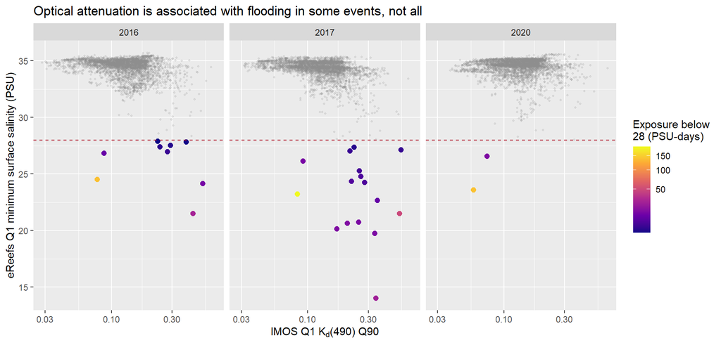

| Year | Group | Cells | Median Kd490 | Median minimum salinity |
| --- | --- | --- | --- | --- |
| 2016 | No exposure below 28 | 3697 | 0.129 | 34.68 |
| 2016 | Any exposure below 28 | 9 | 0.276 | 26.96 |
| 2017 | No exposure below 28 | 3690 | 0.128 | 34.44 |
| 2017 | Any exposure below 28 | 16 | 0.254 | 23.72 |
| 2020 | No exposure below 28 | 3705 | 0.136 | 34.62 |
| 2020 | Any exposure below 28 | 2 | 0.066 | 25.08 |

# Leave-one-event-out validation

Four occurrence models are compared. The spatial terms are a static reconstruction prior: they learn where low-salinity exposure has occurred in other events, but receive no information from the held-out event. This is appropriate for reconstructing 2024 at known GBR locations, not for forecasting novel locations.

Two continuous models then attempt the harder task of predicting minimum salinity. Tail MAE and the fraction of truly flooded cells predicted below 28 PSU are the decisive diagnostics.

Average precision is the principal occurrence metric because fewer than 0.5% of cells are exposed below 28 PSU. Its no-skill value is the event prevalence. ROC AUC is retained but can appear optimistic under that imbalance. Balanced Brier gives flooded and non-flooded cells equal weight, and top-1% recall asks whether a practical risk screen actually captures the flooded cells.

Event-balanced leave-one-event-out occurrence performance

| Model | ROC AUC | Average precision | Balanced Brier | Top 1% recall |
| --- | --- | --- | --- | --- |
| Spatial prior only | 0.984 | 0.549 | 0.282 | 0.611 |
| Kd490 + spatial prior | 0.982 | 0.507 | 0.275 | 0.627 |
| Kd490 only | 0.570 | 0.071 | 0.490 | 0.215 |
| Intercept only | 0.500 | 0.002 | 0.498 | 0.042 |

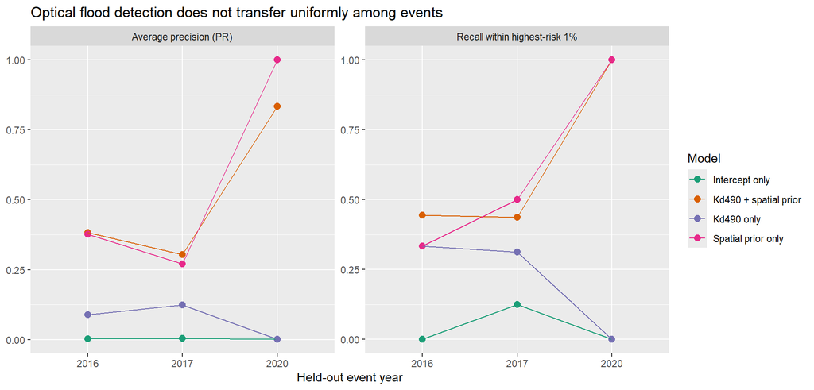

Leave-one-event-out minimum-salinity prediction. Positive flood-cell bias means harmful freshening is underestimated.

| Model | Held-out year | All-cell MAE | Flood-cell MAE | Flood-cell bias | Flood cells predicted below 28 |
| --- | --- | --- | --- | --- | --- |
| Kd490 + spatial prior | 2016 | 0.34 | 6.54 | 6.54 | 0% |
| Kd490 + spatial prior | 2017 | 0.41 | 10.32 | 10.32 | 0% |
| Kd490 + spatial prior | 2020 | 0.34 | 6.99 | 6.99 | 0% |
| Kd490 only | 2016 | 0.58 | 7.37 | 7.37 | 0% |
| Kd490 only | 2017 | 0.51 | 10.82 | 10.82 | 0% |
| Kd490 only | 2020 | 0.57 | 9.63 | 9.63 | 0% |

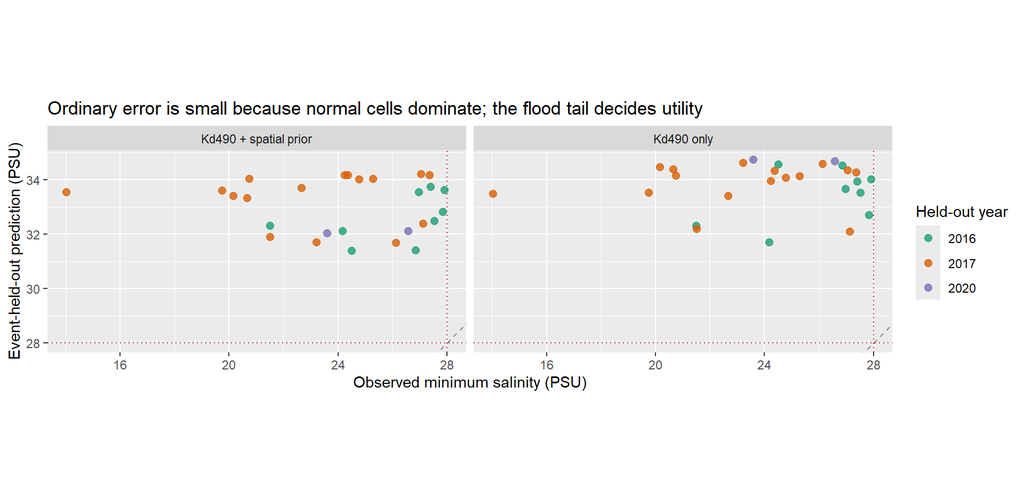

# Exploratory 2024 optical reconstruction

The following reconstruction is generated to show what the optical model would imply, not to fill the primary mortality predictor table. It uses all three complete, unflagged historical events and the full-Q1 2024 IMOS metric. The observed eReefs overlay covers only 1–17 January.

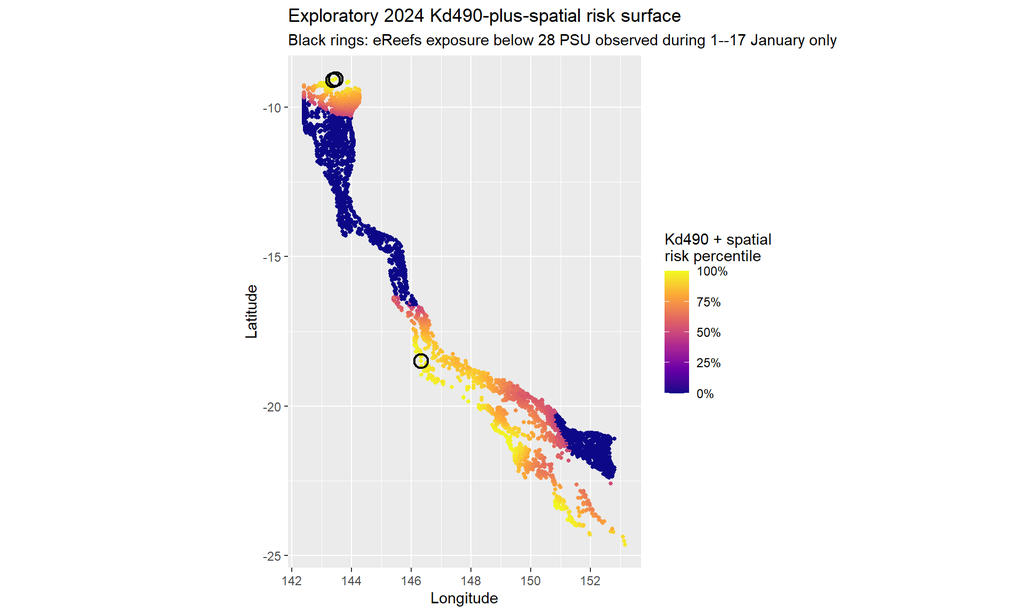

All three low-salinity cells available in the partial 2024 eReefs record fall at or above the 99.5% Kd490-plus-spatial risk percentile. Their Kd490-only percentiles span 7.3% to 99.1%, showing how strongly the combined result relies on the spatial prior. This supports retaining a ranked sensitivity layer, but not calling it satellite salinity. It also does not rescue numeric salinity imputation: their observed partial-period minima range from 23.4 to 25.6 PSU, whereas the candidate full-quarter model predicts 31.6 to 31.7 PSU. These periods are not temporally aligned, so the comparison is descriptive; the held-out historical tail errors provide the formal reason for rejection.

# Recommendation

The optical analysis is retained as a *plume/flood-risk sensitivity*, because it can contain ecologically relevant information that direct heat metrics do not. It is not promoted to a quantitative salinity imputation for the primary mortality model unless event-held-out results show consistent low-salinity-tail performance. In particular:

1. Do not replace missing February–March 2024 salinity with the smooth `candidate_salinity_min_q1` values merely because all-cell MAE is small.
2. Keep the existing IMOS acute optical predictor in the formal BRMS and BRT models; it is observed consistently through the 2024 event.
3. Use the saved, explicitly separated Kd490-only, spatial-only, and combined risk percentiles only as sensitivity covariates or stratification layers, with `use_in_primary_mortality_model = FALSE`.
4. Revisit direct salinity only when a consistent 2024 hydrodynamic product or an independent in-situ/satellite salinity validation source is available.

This prevents a model-derived environmental covariate from being treated as a measurement and avoids giving a visually plausible map more certainty than the event-transfer tests support.